# Analyze A/B Test Results

- Introduction
- Part I - Probability
- Part II - A/B Test
  - Compare to Built_in T-Test
- Part III - Regression
  - Logistic Regression
  - Consider Additional Variables
  - Consider Time Factor
- Conclusions

### Introduction

An A/B test was performed to test changes on webpages of an e-commerce website, by running hypothesis testing, to help determine if the website should implement the new page or keep the old page.

#### Part I - Probability

Import the libraries.

```python
import pandas as pd
import numpy as np
import random
import matplotlib.pyplot as plt
%matplotlib inline
#We are setting the seed to assure you get the same answers on quizzes as we set up
random.seed(42)
```

Read in the dataset and take a look at the top few rows here:

```python
df = pd.read_csv('ab_data.csv')
df.head()
```

|  | user_id | timestamp | group | landing_page | converted |
| --- | --- | --- | --- | --- | --- |
| 0 | 851104 | 2017-01-21 22:11:48.556739 | control | old_page | 0 |
| 1 | 804228 | 2017-01-12 08:01:45.159739 | control | old_page | 0 |
| 2 | 661590 | 2017-01-11 16:55:06.154213 | treatment | new_page | 0 |
| 3 | 853541 | 2017-01-08 18:28:03.143765 | treatment | new_page | 0 |
| 4 | 864975 | 2017-01-21 01:52:26.210827 | control | old_page | 1 |

The number of rows in the dataset.

```python
df.shape
```

```
(294478, 5)
```

The number of unique users in the dataset.

```python
df['user_id'].nunique()
```

```
290584
```

The proportion of users converted.

```python
df.query('converted == 1')['user_id'].nunique() / df['user_id'].nunique()
```

```
0.12104245244060237
```

The number of times the `new_page` and `treatment` don't match.

```python
df[((df['group'] == 'treatment') == (df['landing_page'] == 'new_page')) == False].shape[0]
```

```
3893
```

The missing values

```python
df.info()
```

```
<class 'pandas.core.frame.DataFrame'>
RangeIndex: 294478 entries, 0 to 294477
Data columns (total 5 columns):
user_id         294478 non-null int64
timestamp       294478 non-null object
group           294478 non-null object
landing_page    294478 non-null object
converted       294478 non-null int64
dtypes: int64(2), object(3)
memory usage: 11.2+ MB
```

##### Conclusion

> There's no missing values exist.

Create a new dataset **df2**, without the rows where **treatment** does not match with **new_page** or **control** does not match with **old_page**, we cannot be sure if this row truly received the new or old page.

```python
df2 = df[((df['group'] == 'treatment') & (df['landing_page'] == 'new_page')) | ((df['group'] == 'control') & (df['landing_page'] == 'old_page'))]
df2.head()
```

|  | user_id | timestamp | group | landing_page | converted |
| --- | --- | --- | --- | --- | --- |
| 0 | 851104 | 2017-01-21 22:11:48.556739 | control | old_page | 0 |
| 1 | 804228 | 2017-01-12 08:01:45.159739 | control | old_page | 0 |
| 2 | 661590 | 2017-01-11 16:55:06.154213 | treatment | new_page | 0 |
| 3 | 853541 | 2017-01-08 18:28:03.143765 | treatment | new_page | 0 |
| 4 | 864975 | 2017-01-21 01:52:26.210827 | control | old_page | 1 |

```python
# Double Check all of the correct rows were removed - this should be 0
df2[((df2['group'] == 'treatment') == (df2['landing_page'] == 'new_page')) == False].shape[0]
```

```
0
```

The number of the unique **user_id**s in **df2**.

```python
df2['user_id'].nunique()
```

```
290584
```

Remove the **user_id** that repeated in **df2**.

```python
df2[df2['user_id'].duplicated()]
```

|  | user_id | timestamp | group | landing_page | converted |
| --- | --- | --- | --- | --- | --- |
| 2893 | 773192 | 2017-01-14 02:55:59.590927 | treatment | new_page | 0 |

```python
df2[df2['user_id'].duplicated()]['user_id']
```

```
2893    773192
Name: user_id, dtype: int64
```

```python
# Remove the duplicate row
df2.drop_duplicates('user_id', inplace = True)
```

```python
# Double check
df2[df2['user_id'].duplicated()]
```

|  | user_id | timestamp | group | landing_page | converted |
| --- | --- | --- | --- | --- | --- |

> The row with duplicated **user_id** is successfully removed.

The probability of an individual converting regardless of the page they receive.

```python
convert_mean = df2['converted'].mean()
convert_mean
```

```
0.11959708724499628
```

The probability of converted, given that an individual was in the `control` group.

```python
prop_con_control = df2.query('group == "control"')['converted'].mean()
prop_con_control
```

```
0.1203863045004612
```

The probability of converted, given that an individual was in the `treatment` group.

```python
prop_con_treatment = df2.query('group == "treatment"')['converted'].mean()
prop_con_treatment
```

```
0.11880806551510564
```

The probability that an individual received the new page.

```python
df2[df2['landing_page'] == 'new_page']['user_id'].count() / df2.shape[0]
```

```
0.50006194422266881
```

##### Conclusions

> - Althrough the conversion rate for the control group (0.1203) is slightly higher than the conversion rate of the treatment group (0.1188), it's still no sufficient evidence that the difference between these two groups is significant.
> - The reasons of the conversion rates for the control group and treatment group might be change aversion and novelty effect.
> - To get more support for the decision of whether implement the new page or keep the old one, we should set up a hypothesis test and calculate the p-value to determine the statistical significance of the observed difference.

### Part II - A/B Test

Assume that the old page is better unless the new page proves to be definitely better at a Type I error rate of 5%.

##### Hypothesis:

$$ H_0: \ p_{new} - \ p_{old} \leqslant 0 $$

$$ H_1: \ p_{new} - \ p_{old} > 0 $$

$\ p_{new}$ and $\ p_{old}$ are the population mean value for the conversion rates of the treatment group and control group, respectively.

Assume under the null hypothesis, $p_{new}$ and $p_{old}$ both have "true" success rates equal to the **converted** success rate regardless of page - that is $p_{new}$ and $p_{old}$ are equal. Furthermore, assume they are equal to the **converted** rate in **ab_data.csv** regardless of the page.

Use a sample size for each page equal to the ones in **ab_data.csv**.

Perform the sampling distribution for the difference in **converted** between the two pages over 10,000 iterations of calculating an estimate from the null.

The **conversion rate** for $p_{new}$ under the null.

```python
# As the assumption above, p_old = p_new = convert_mean
p_new = convert_mean
p_new
```

```
0.11959708724499628
```

The **conversion rate** for $p_{old}$ under the null.

```python
p_old = convert_mean
p_old
```

```
0.11959708724499628
```

The number of individuals in the **treatment** group.

```python
n_new = df2.query('landing_page == "new_page"').shape[0]
n_new
```

```
145310
```

The number of individuals in the **control** group.

```python
n_old = df2.query('landing_page == "old_page"').shape[0]
n_old
```

```
145274
```

Simulate $n_{new}$ transactions with a conversion rate of $p_{new}$ under the null.

```python
new_page_converted = np.random.choice([1,0], size = n_new, p = [p_new, 1 - p_new]).mean()
new_page_converted
```

```
0.1192760305553644
```

Simulate **n_new** transactions with a conversion rate of **𝑝_𝑛𝑒𝑤** under the null.

```python
old_page_converted = np.random.choice([1,0], size = n_old, p = [p_old, 1 - p_old]).mean()
old_page_converted
```

```
0.11875490452524196
```

Find $p_{new}$ - $p_{old}$ for the simulated values.

```python
obs_diff = new_page_converted - old_page_converted
obs_diff
```

```
0.00052112603012244296
```

Simulate the sampling distribution for 10000 times.

```python
p_diffs = []

for _ in range(10000):
    new_converted_sim = np.random.choice([1,0], size = n_new, p = [p_new, 1 - p_new]).mean()
    old_converted_sim = np.random.choice([1,0], size = n_old, p = [p_old, 1 - p_old]).mean()
    p_diffs.append(new_converted_sim - old_converted_sim)
```

Plot a histogram of the **p_diffs**.

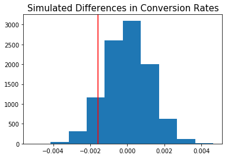

```python
plt.hist(p_diffs);
plt.title('Simulated Differences in Conversion Rates', fontsize = 15);
plt.axvline(prop_con_treatment - prop_con_control, color = 'r');
```

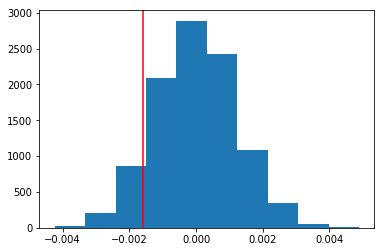

```python
# Simulate distribution under the null hypothesis
null_vals = np.random.normal(0, np.std(p_diffs), len(p_diffs))

plt.hist(null_vals);
plt.axvline(x = prop_con_treatment - prop_con_control, color = 'r');
```

```python
# Probability of a statstic higher than observed mean
(null_vals > obs_diff).mean()
```

```
0.32740000000000002
```

##### Conclusion

> This value is p-value. The p-value is larger than 0.05 (alpha level) that we're failed to reject the null hypothesis and keep the old page.

### Compare to Built-in T-test

```python
import statsmodels.api as sm

convert_old = df2.query('group == "control" and converted == 1')['converted'].count()
convert_new = df2.query('group == "treatment" and converted == 1')['converted'].count()
n_old = df2.query('landing_page == "old_page"')['user_id'].count()
n_new = df2.query('landing_page == "new_page"')['user_id'].count()
```

```python
convert_new, convert_old, n_new, n_old
```

```
(17264, 17489, 145310, 145274)
```

Us stats.proportions_ztest to compute the test statistic and p-value.

```python
z_score, p_value = sm.stats.proportions_ztest([convert_new, convert_old], [n_new, n_old], alternative = 'larger')
z_score, p_value
```

```
(-1.3109241984234394, 0.90505831275902449)
```

##### Conclusion

> The z-score indicates the value is 1.31 standard deviations below the mean. The p-value is 90.51%, which is large enough to reach the conclusion that we are failed to reject the null hypothesis. This conclusion is aligned with the conclusion obtained from the hypothesis testing.

### Part III - A regression approach

The selection of regression model.

##### Logistic Regression

Since there are two outcomes, converted or not converted, in this case, we should perform logistic regression here.

```python
# Dummy variables
df2[['ab_page', 'old_page']] = pd.get_dummies(df2['landing_page'])

# Create intercept column
df2['intercept'] = 1
df2.head()
```

|  | user_id | timestamp | group | landing_page | converted | ab_page | old_page | intercept |
| --- | --- | --- | --- | --- | --- | --- | --- | --- |
| 0 | 851104 | 2017-01-21 22:11:48.556739 | control | old_page | 0 | 0 | 1 | 1 |
| 1 | 804228 | 2017-01-12 08:01:45.159739 | control | old_page | 0 | 0 | 1 | 1 |
| 2 | 661590 | 2017-01-11 16:55:06.154213 | treatment | new_page | 0 | 1 | 0 | 1 |
| 3 | 853541 | 2017-01-08 18:28:03.143765 | treatment | new_page | 0 | 1 | 0 | 1 |
| 4 | 864975 | 2017-01-21 01:52:26.210827 | control | old_page | 1 | 0 | 1 | 1 |

Instantiate and fit the model.

```python
logit_mod = sm.Logit(df2['converted'], df2[['intercept', 'ab_page']])
```

Summary of result.

```python
results = logit_mod.fit()
results.summary()
```

```
Optimization terminated successfully.
         Current function value: 0.366118
         Iterations 6
```

Logit Regression Results

| Dep. Variable: | converted | No. Observations: | 290584 |
| --- | --- | --- | --- |
| Model: | Logit | Df Residuals: | 290582 |
| Method: | MLE | Df Model: | 1 |
| Date: | Sat, 13 Jul 2019 | Pseudo R-squ.: | 8.077e-06 |
| Time: | 18:27:03 | Log-Likelihood: | -1.0639e+05 |
| converged: | True | LL-Null: | -1.0639e+05 |
|  |  | LLR p-value: | 0.1899 |

|  | coef | std err | z | P>\|z\| | [0.025 | 0.975] |
| --- | --- | --- | --- | --- | --- | --- |
| intercept | -1.9888 | 0.008 | -246.669 | 0.000 | -2.005 | -1.973 |
| ab_page | -0.0150 | 0.011 | -1.311 | 0.190 | -0.037 | 0.007 |

##### Conclusions

> The logistic regression model assumes: $$ H_0: \ p_{new} - \ p_{old} = 0 $$
> $$ H_1: \ p_{new} - \ p_{old} \neq 0 $$
> In hypothesis testing, we performed a one-sided test, but in logistic regression, it is a two-sided test. Since $ H_1 $ changed, the p-value changed.

### Consider Additional Variables

Considering other factors is a good idea in this case. Because these factors might contribute to the significance of the result, and make it more accurate. But considering additional factors may lead to Simpson's Paradox, which means, the trend might be reversed after considering additional factors, as the trend usually appears when the variables are tested separately.

Combine two datasets.

```python
countries_df = pd.read_csv('countries.csv')
countries_df.head()
```

|  | user_id | country |
| --- | --- | --- |
| 0 | 834778 | UK |
| 1 | 928468 | US |
| 2 | 822059 | UK |
| 3 | 711597 | UK |
| 4 | 710616 | UK |

```python
# Combine two datasets
df_new = countries_df.set_index('user_id').join(df2.set_index('user_id'), how = 'inner')
df_new.head()
```

| user_id | country | timestamp | group | landing_page | converted | ab_page | old_page | intercept |
| --- | --- | --- | --- | --- | --- | --- | --- | --- |
| 834778 | UK | 2017-01-14 23:08:43.304998 | control | old_page | 0 | 0 | 1 | 1 |
| 928468 | US | 2017-01-23 14:44:16.387854 | treatment | new_page | 0 | 1 | 0 | 1 |
| 822059 | UK | 2017-01-16 14:04:14.719771 | treatment | new_page | 1 | 1 | 0 | 1 |
| 711597 | UK | 2017-01-22 03:14:24.763511 | control | old_page | 0 | 0 | 1 | 1 |
| 710616 | UK | 2017-01-16 13:14:44.000513 | treatment | new_page | 0 | 1 | 0 | 1 |

```python
# Dummy variables
df_new[['CA', 'UK', 'US']] = pd.get_dummies(df_new['country'])
df_new.head()
```

| user_id | country | timestamp | group | landing_page | converted | ab_page | old_page | intercept | CA | UK | US |
| --- | --- | --- | --- | --- | --- | --- | --- | --- | --- | --- | --- |
| 834778 | UK | 2017-01-14 23:08:43.304998 | control | old_page | 0 | 0 | 1 | 1 | 0 | 1 | 0 |
| 928468 | US | 2017-01-23 14:44:16.387854 | treatment | new_page | 0 | 1 | 0 | 1 | 0 | 0 | 1 |
| 822059 | UK | 2017-01-16 14:04:14.719771 | treatment | new_page | 1 | 1 | 0 | 1 | 0 | 1 | 0 |
| 711597 | UK | 2017-01-22 03:14:24.763511 | control | old_page | 0 | 0 | 1 | 1 | 0 | 1 | 0 |
| 710616 | UK | 2017-01-16 13:14:44.000513 | treatment | new_page | 0 | 1 | 0 | 1 | 0 | 1 | 0 |

Instantiate and fit the model.

```python
# Logistic Regression Model
logit_mod = sm.Logit(df_new['converted'], df_new[['intercept', 'US', 'UK']])
results = logit_mod.fit()
results.summary()
```

```
Optimization terminated successfully.
         Current function value: 0.366116
         Iterations 6
```

Logit Regression Results

| Dep. Variable: | converted | No. Observations: | 290584 |
| --- | --- | --- | --- |
| Model: | Logit | Df Residuals: | 290581 |
| Method: | MLE | Df Model: | 2 |
| Date: | Sat, 13 Jul 2019 | Pseudo R-squ.: | 1.521e-05 |
| Time: | 18:35:46 | Log-Likelihood: | -1.0639e+05 |
| converged: | True | LL-Null: | -1.0639e+05 |
|  |  | LLR p-value: | 0.1984 |

|  | coef | std err | z | P>\|z\| | [0.025 | 0.975] |
| --- | --- | --- | --- | --- | --- | --- |
| intercept | -2.0375 | 0.026 | -78.364 | 0.000 | -2.088 | -1.987 |
| US | 0.0408 | 0.027 | 1.518 | 0.129 | -0.012 | 0.093 |
| UK | 0.0507 | 0.028 | 1.786 | 0.074 | -0.005 | 0.106 |

##### Conclusion

> - The p-values for the countries ('US' and 'UK') are all larger than 0.05 (alpha), so we are failed to reject the null hypothesis.
> - The countries variable makes no significant contributions to differences in conversion rate.

Check the interaction between country and page.

```python
df_new['US_page'] = df_new['US'] * df_new['ab_page']
df_new['UK_page'] = df_new['UK'] * df_new['ab_page']
df_new.head()
```

| user_id | country | timestamp | group | landing_page | converted | ab_page | old_page | intercept | CA | UK | US | US_page | UK_page |
| --- | --- | --- | --- | --- | --- | --- | --- | --- | --- | --- | --- | --- | --- |
| 834778 | UK | 2017-01-14 23:08:43.304998 | control | old_page | 0 | 0 | 1 | 1 | 0 | 1 | 0 | 0 | 0 |
| 928468 | US | 2017-01-23 14:44:16.387854 | treatment | new_page | 0 | 1 | 0 | 1 | 0 | 0 | 1 | 1 | 0 |
| 822059 | UK | 2017-01-16 14:04:14.719771 | treatment | new_page | 1 | 1 | 0 | 1 | 0 | 1 | 0 | 0 | 1 |
| 711597 | UK | 2017-01-22 03:14:24.763511 | control | old_page | 0 | 0 | 1 | 1 | 0 | 1 | 0 | 0 | 0 |
| 710616 | UK | 2017-01-16 13:14:44.000513 | treatment | new_page | 0 | 1 | 0 | 1 | 0 | 1 | 0 | 0 | 1 |

```python
# Logistic Regression fitting for interaction
log_mod = sm.Logit(df_new['converted'], df_new[['intercept', 'US', 'UK', 'ab_page', 'US_page', 'UK_page']])
results = log_mod.fit()
results.summary()
```

```
Optimization terminated successfully.
         Current function value: 0.366109
         Iterations 6
```

Logit Regression Results

| Dep. Variable: | converted | No. Observations: | 290584 |
| --- | --- | --- | --- |
| Model: | Logit | Df Residuals: | 290578 |
| Method: | MLE | Df Model: | 5 |
| Date: | Sat, 13 Jul 2019 | Pseudo R-squ.: | 3.482e-05 |
| Time: | 18:36:58 | Log-Likelihood: | -1.0639e+05 |
| converged: | True | LL-Null: | -1.0639e+05 |
|  |  | LLR p-value: | 0.1920 |

|  | coef | std err | z | P>\|z\| | [0.025 | 0.975] |
| --- | --- | --- | --- | --- | --- | --- |
| intercept | -2.0040 | 0.036 | -55.008 | 0.000 | -2.075 | -1.933 |
| US | 0.0175 | 0.038 | 0.465 | 0.642 | -0.056 | 0.091 |
| UK | 0.0118 | 0.040 | 0.296 | 0.767 | -0.066 | 0.090 |
| ab_page | -0.0674 | 0.052 | -1.297 | 0.195 | -0.169 | 0.034 |
| US_page | 0.0469 | 0.054 | 0.872 | 0.383 | -0.059 | 0.152 |
| UK_page | 0.0783 | 0.057 | 1.378 | 0.168 | -0.033 | 0.190 |

##### Conclusion

> Based on the results above, all of these variables has p-value larger than 0.05 (alpha level). Thus, we're failed to reject the null hypothesis and reach the conclusion that there's no enough evidence to support that the interaction between page and country has significant effect on conversion.

### Consider the Time Factor

```python
df_new.info()
```

```
<class 'pandas.core.frame.DataFrame'>
Int64Index: 290584 entries, 834778 to 934996
Data columns (total 13 columns):
country         290584 non-null object
timestamp       290584 non-null object
group           290584 non-null object
landing_page    290584 non-null object
converted       290584 non-null int64
ab_page         290584 non-null uint8
old_page        290584 non-null uint8
intercept       290584 non-null int64
CA              290584 non-null uint8
UK              290584 non-null uint8
US              290584 non-null uint8
US_page         290584 non-null uint8
UK_page         290584 non-null uint8
dtypes: int64(2), object(4), uint8(7)
memory usage: 17.5+ MB
```

```python
# Convert 'timestamp' from object to datetime
df_new['timestamp'] = pd.to_datetime(df_new['timestamp'])
df_new.info()
```

```
<class 'pandas.core.frame.DataFrame'>
Int64Index: 290584 entries, 834778 to 934996
Data columns (total 13 columns):
country         290584 non-null object
timestamp       290584 non-null datetime64[ns]
group           290584 non-null object
landing_page    290584 non-null object
converted       290584 non-null int64
ab_page         290584 non-null uint8
old_page        290584 non-null uint8
intercept       290584 non-null int64
CA              290584 non-null uint8
UK              290584 non-null uint8
US              290584 non-null uint8
US_page         290584 non-null uint8
UK_page         290584 non-null uint8
dtypes: datetime64[ns](1), int64(2), object(3), uint8(7)
memory usage: 17.5+ MB
```

```python
df_new.head()
```

| user_id | country | timestamp | group | landing_page | converted | ab_page | old_page | intercept | CA | UK | US | US_page | UK_page |
| --- | --- | --- | --- | --- | --- | --- | --- | --- | --- | --- | --- | --- | --- |
| 834778 | UK | 2017-01-14 23:08:43.304998 | control | old_page | 0 | 0 | 1 | 1 | 0 | 1 | 0 | 0 | 0 |
| 928468 | US | 2017-01-23 14:44:16.387854 | treatment | new_page | 0 | 1 | 0 | 1 | 0 | 0 | 1 | 1 | 0 |
| 822059 | UK | 2017-01-16 14:04:14.719771 | treatment | new_page | 1 | 1 | 0 | 1 | 0 | 1 | 0 | 0 | 1 |
| 711597 | UK | 2017-01-22 03:14:24.763511 | control | old_page | 0 | 0 | 1 | 1 | 0 | 1 | 0 | 0 | 0 |
| 710616 | UK | 2017-01-16 13:14:44.000513 | treatment | new_page | 0 | 1 | 0 | 1 | 0 | 1 | 0 | 0 | 1 |

```python
# Extract 'timestamp' to 'timestamp_date'
df_new['timestamp_date'] = pd.to_datetime(df_new['timestamp']).dt.date
```

```python
# Convert 'timestamp_date' from object to datetime
df_new['timestamp_date'] = pd.to_datetime(df_new['timestamp_date'])
df_new.info()
```

```
<class 'pandas.core.frame.DataFrame'>
Int64Index: 290584 entries, 834778 to 934996
Data columns (total 14 columns):
country           290584 non-null object
timestamp         290584 non-null datetime64[ns]
group             290584 non-null object
landing_page      290584 non-null object
converted         290584 non-null int64
ab_page           290584 non-null uint8
old_page          290584 non-null uint8
intercept         290584 non-null int64
CA                290584 non-null uint8
UK                290584 non-null uint8
US                290584 non-null uint8
US_page           290584 non-null uint8
UK_page           290584 non-null uint8
timestamp_date    290584 non-null datetime64[ns]
dtypes: datetime64[ns](2), int64(2), object(3), uint8(7)
memory usage: 19.7+ MB
```

```python
# Convert 'timestamp_date' to day of week
df_new['timestamp_wd'] = df_new['timestamp_date'].dt.weekday_name
df_new.head()
```

| user_id | country | timestamp | group | landing_page | converted | ab_page | old_page | intercept | CA | UK | US | US_page | UK_page | timestamp_date | timestamp_wd |
| --- | --- | --- | --- | --- | --- | --- | --- | --- | --- | --- | --- | --- | --- | --- | --- |
| 834778 | UK | 2017-01-14 23:08:43.304998 | control | old_page | 0 | 0 | 1 | 1 | 0 | 1 | 0 | 0 | 0 | 2017-01-14 | Saturday |
| 928468 | US | 2017-01-23 14:44:16.387854 | treatment | new_page | 0 | 1 | 0 | 1 | 0 | 0 | 1 | 1 | 0 | 2017-01-23 | Monday |
| 822059 | UK | 2017-01-16 14:04:14.719771 | treatment | new_page | 1 | 1 | 0 | 1 | 0 | 1 | 0 | 0 | 1 | 2017-01-16 | Monday |
| 711597 | UK | 2017-01-22 03:14:24.763511 | control | old_page | 0 | 0 | 1 | 1 | 0 | 1 | 0 | 0 | 0 | 2017-01-22 | Sunday |
| 710616 | UK | 2017-01-16 13:14:44.000513 | treatment | new_page | 0 | 1 | 0 | 1 | 0 | 1 | 0 | 0 | 1 | 2017-01-16 | Monday |

```python
# Dummy variables
df_new[['Fri', 'Mon', 'Sat', 'Sun', 'Thu', 'Tue', 'Wed']] = pd.get_dummies(df_new['timestamp_wd'])
df_new.head()
```

| user_id | country | timestamp | group | landing_page | converted | ab_page | old_page | intercept | CA | UK | ... | UK_page | timestamp_date | timestamp_wd | Fri | Mon | Sat | Sun | Thu | Tue | Wed |
| --- | --- | --- | --- | --- | --- | --- | --- | --- | --- | --- | --- | --- | --- | --- | --- | --- | --- | --- | --- | --- | --- |
| 834778 | UK | 2017-01-14 23:08:43.304998 | control | old_page | 0 | 0 | 1 | 1 | 0 | 1 | ... | 0 | 2017-01-14 | Saturday | 0 | 0 | 1 | 0 | 0 | 0 | 0 |
| 928468 | US | 2017-01-23 14:44:16.387854 | treatment | new_page | 0 | 1 | 0 | 1 | 0 | 0 | ... | 0 | 2017-01-23 | Monday | 0 | 1 | 0 | 0 | 0 | 0 | 0 |
| 822059 | UK | 2017-01-16 14:04:14.719771 | treatment | new_page | 1 | 1 | 0 | 1 | 0 | 1 | ... | 1 | 2017-01-16 | Monday | 0 | 1 | 0 | 0 | 0 | 0 | 0 |
| 711597 | UK | 2017-01-22 03:14:24.763511 | control | old_page | 0 | 0 | 1 | 1 | 0 | 1 | ... | 0 | 2017-01-22 | Sunday | 0 | 0 | 0 | 1 | 0 | 0 | 0 |
| 710616 | UK | 2017-01-16 13:14:44.000513 | treatment | new_page | 0 | 1 | 0 | 1 | 0 | 1 | ... | 1 | 2017-01-16 | Monday | 0 | 1 | 0 | 0 | 0 | 0 | 0 |

5 rows × 22 columns

```python
# Logistic Regression fitting
logit_mod = sm.Logit(df_new['converted'], df_new[['intercept', 'Fri', 'Mon', 'Sat', 'Thu', 'Tue', 'Wed']])
results = logit_mod.fit()
results.summary()
```

```
Optimization terminated successfully.
         Current function value: 0.366112
         Iterations 6
```

Logit Regression Results

| Dep. Variable: | converted | No. Observations: | 290584 |
| --- | --- | --- | --- |
| Model: | Logit | Df Residuals: | 290577 |
| Method: | MLE | Df Model: | 6 |
| Date: | Sat, 13 Jul 2019 | Pseudo R-squ.: | 2.601e-05 |
| Time: | 18:43:09 | Log-Likelihood: | -1.0639e+05 |
| converged: | True | LL-Null: | -1.0639e+05 |
|  |  | LLR p-value: | 0.4774 |

|  | coef | std err | z | P>\|z\| | [0.025 | 0.975] |
| --- | --- | --- | --- | --- | --- | --- |
| intercept | -2.0069 | 0.015 | -129.579 | 0.000 | -2.037 | -1.977 |
| Fri | -0.0172 | 0.022 | -0.782 | 0.434 | -0.060 | 0.026 |
| Mon | 0.0253 | 0.021 | 1.199 | 0.231 | -0.016 | 0.067 |
| Sat | 0.0223 | 0.022 | 1.020 | 0.308 | -0.021 | 0.065 |
| Thu | 0.0141 | 0.022 | 0.644 | 0.519 | -0.029 | 0.057 |
| Tue | 0.0101 | 0.021 | 0.482 | 0.630 | -0.031 | 0.051 |
| Wed | 0.0177 | 0.022 | 0.807 | 0.420 | -0.025 | 0.061 |

##### Conclusions

> After taking the time into consideration, the result of logistic regression model indicates that the p-values for these variables are larger than 0.05 (alpha level). Thus, there's no significant effect on the conversion rate based on the time.

## Conclusions

> - According to the result of hypothesis testing and built-in t-test, the p-value is larger than 0.05, so we're failed to reject the null hypothesis.
> - In the result of logistic regression model, there's no significant difference between the conversion rates of ab_page and old_page, based on 'country' and 'the day of week'.
> - We cannot make the final decision till now, due to the limited data.